# Presentación Examen Final

Jorge III Altamirano Astorga (175904) Uriel Miranda Miñon (177508)  
2017/12/02

## What's Cooking

### Dataset by Yummly

### Objetivo

Determinar en base a los ingredientes el tipo de cocina a la que pertenece un platillo.

Existen alrededor más de 6,000 ingredients en el dataset de entrenamiento (unclean):

- Con 39,774 observaciones para el set de entrenamiento
- Clasificados en 20 tipos de cocinas: mexicana, francesa, tailandesa, …

Para el set de prueba son 9,944 observaciones.

Dentro de Aprendizaje Máquina éste es un problema de Aprendizaje Supervisado y de Clasificación.

### Datos 1 de 3

Los datos están en formato JSON, con una lista anidada y el ID en desorden como se muestra aquí.

```r
train <- fromJSON("data/train.json")
train <- train %>% as.data.frame
train %>% head(n=4) %>% kable
```

| id | cuisine | ingredients |
| --- | --- | --- |
| 10259 | greek | romaine lettuce, black olives, grape tomatoes, garlic, pepper, purple onion, seasoning, garbanzo beans, feta cheese crumbles |
| 25693 | southern_us | plain flour, ground pepper, salt, tomatoes, ground black pepper, thyme, eggs, green tomatoes, yellow corn meal, milk, vegetable oil |
| 20130 | filipino | eggs, pepper, salt, mayonaise, cooking oil, green chilies, grilled chicken breasts, garlic powder, yellow onion, soy sauce, butter, chicken livers |
| 22213 | indian | water, vegetable oil, wheat, salt |

### Datos 2 de 3

Los datos van a requerir algo de limpieza, como es usual:

- Existen ingredientes repetidos, dado que contienen cantidades o porcentajes
- Existen ingredientes repetidos con caracteres especiales o acentuados
- Consideramos más conveniente convertir a minúsculas

```r
train$ingredients %>% unlist %>%  tolower %>%unique %>% data.frame(x=.) %>% arrange(x) %>%  head(n=10) %>% kable
```

| x |
| --- |
| ( oz.) tomato sauce |
| ( oz.) tomato paste |
| (10 oz.) frozen chopped spinach |
| (10 oz.) frozen chopped spinach, thawed and squeezed dry |
| (14 oz.) sweetened condensed milk |
| (14.5 oz.) diced tomatoes |
| (15 oz.) refried beans |
| 1% low-fat buttermilk |
| 1% low-fat chocolate milk |
| 1% low-fat cottage cheese |

### Datos 3 de 3

Data summary después de una breve limpieza, aún así requerimos trabajar en:

- Separar la lista de ingredientes: se nos ocurre hacer una variable por cada ingrediente (los +6,000)
- Dichas 6,000 variables serán nuestras \( x \) y nuestra \( y \) (objetivo) será `cuisine`
- También requiere cambiar los espacios (“ ”) por “`_`” en dichas variables

| id | cuisine | ingredients |
| --- | --- | --- |
| 0 | spanish | mussels, ground black pepper, garlic cloves, saffron threads, olive oil, stewed tomatoes, arborio rice, minced onion, medium shrimp, fat free less sodium chicken broth, green peas |
| 1 | mexican | tomatoes, diced red onions, paprika, salt, corn tortillas, fresh cilantro, cremini, vegetable broth, freshly ground pepper, ground chipotle chile pepper, bell pepper, extra-virgin olive oil, yellow on… |
| 2 | french | chicken broth, truffles, pimentos, green pepper, olives, roast turkey, egg yolks, heavy cream, tarragon leaves, eggs, flour, butter, scallions, cold water, unflavored gelatin, leeks, salt, aspic |

### Datos 3 de 3

Antes

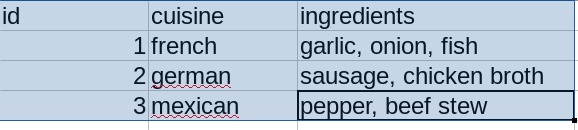

Después

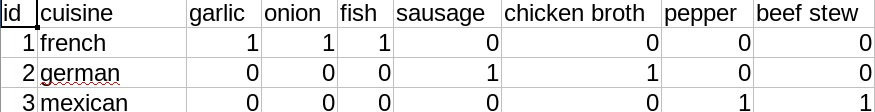

### Métodos

Pretendemos utilizar los siguientes métodos:

## **#1 Support Vector Machine: Multi-class classification**

Dado que es un método que nos pareció:

1. Con potencial para este problema
2. Tomando su sugerencia de usar un método no visto en clase

**#2 Regresión Lineal con Lasso:** Por su simplicidad e interpretabilidad.

**#3 Bosques Aleatorios:** Por los buenos resultados que tiene *out of the box*.

### Bibliografía

- [Aprendizaje Máquina - Luis Felipe González](https://felipegonzalez.github.io/aprendizaje-maquina-2017/)
- [kaggle.com/What's cooking](https://www.kaggle.com/c/whats-cooking/data)
- [R SVM @R-Project's Cran](https://cran.r-project.org/web/packages/e1071/vignettes/svmdoc.pdf)